# Animations with R - Tutorial

Francesco Serafini

18/03/2022

# Creating Animations from frame files

Different techniques exists to create Gifs and animations with R. The way that I like the most is to create and store png files representing the frames and glue them together in an animation. Packages exists that does that automatically like $\texttt{gganimate}$ but the syntax may be complicated and, as said, I found this way easier. The packages needed for this are

```r
library(magick) # to create animation
library(magrittr) # to create animation
library(gtools) # to sort file names correctly
```

Below the code to iteratively create the plots representing the animation’s frames. It is just a for loop which creates four plots (the four panels) and arrange them together using Inlabru. It is necessary that the frames are saved in a separate folder with inside the frames only. This is because the next step will be to take all the files in the folder and create the animation from those.

```r
# for each week
for(idx in 1:length(weeks.to.fore)){
  # extract catalogue
  samp.cat <- weeks.to.fore[[idx]]
  # extract locations
  week.data <- samp.cat[,c('x', 'y')]
  # initialize raster
  raster.grid <- raster(bdy, nrows = 50, ncols = 50)
  raster.grid[] <- 0
  # counts per cell
  counts_ <- table(cellFromXY(raster.grid, week.data))
  # cell value become 1 if positive number of events
  raster.grid[as.numeric(names(counts_))] <- 1
  # turn it in SpatialPixels obj for plotting
  week.sp <- as(raster.grid, 'SpatialPixelsDataFrame')
  # turn the catalogue in sf object for plotting on Italy map
  samp.cat.sp <- samp.cat
  coordinates(samp.cat.sp) <- c('x', 'y')
  samp.cat.sf <- st_as_sf(samp.cat.sp)
  st_crs(samp.cat.sf) <- italy.crs
  samp.cat.sf <- st_transform(samp.cat.sf, italy.crs)

  # forecast of activity (produced and stored in the example document)
  pl.pred <- ggplot() +
    gg(list.pixels.prob[[idx]]) +
    labs(title = paste0('Forecast - week ', idx), fill = 'prob') +
    theme(legend.position = 'bottom') +
    scale_fill_viridis(limits = c(0,1))

  # observed activity
  pl.obs <- ggplot() +
    gg(week.sp) +
    labs(title = paste0('Observed - week ', idx), fill = 'activity') +
    theme(legend.position = 'bottom')+
    scale_fill_viridis()
  # observed seismicity - 2D
  p.2d <- ggplot() +
    geom_sf(data = it.map) +
    geom_sf(data = bdy.sf, color = 'green') +
    geom_sf(data = samp.cat.sf, size = 1.5) +
    geom_sf(data = samp.cat.sf[samp.cat.sf$mags >= 5, ], shape = 24, fill = 'red', size = 2.5) +
    labs(title = paste0('week = ', idx))

  week.part <- weeks.to.fore[1:idx]
  NN <- sapply(week.part, nrow)
  # observed seismicity - histogram
  p.bar <- ggplot() + geom_bar(aes(x = 1:idx, y = NN), stat = 'identity') +
    xlim(0,20) +
    ylim(0, max(N.weeks)) +
    geom_vline(xintercept = idx + 0.5) +
    ylab('Counts') +
    xlab('Weeks')


  # save image as png in a specific folder
  png(paste0('image_to_anim/frame', idx, '.png'), width = 480*1.5, height = 480*1.5)

  multiplot(p.2d, p.bar, pl.pred, pl.obs,
            layout = matrix(1:4, byrow = TRUE, ncol = 2))
  dev.off()
}
```

Now, we just need to extract the file names and this vector of files names will be used to create the animation. The frames in the animation will be in the same order as provided in the file names vector, R automatically order them as character (like frame10 before frame2) and we need to use a specific function to get the right sorting (i.e. $\texttt{mixedsort}$).

```r
# extract the files name
nn <- list.files(path='image_to_anim/', pattern = '*.png', full.names = TRUE)
# produce animation
mixedsort(nn) %>%  # this also sorts the files name
        image_read() %>% # reads each path file
        image_join() %>% # joins image
        image_animate(fps=2) %>% # animates, different options are available
        image_write("Fore_activity.gif") # save
```

Then, we can just include them using $\texttt{include_graphics}$ function, unfortunately, it doesn’t work on pdf outputs, but works nicely on html ones.

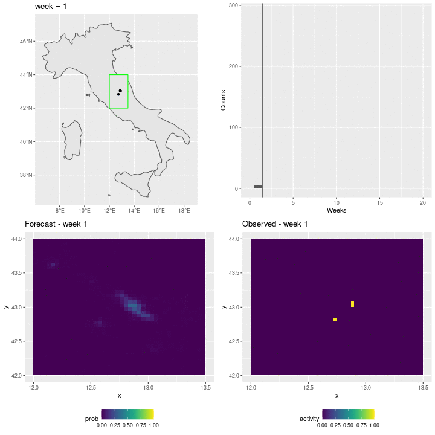

```r
knitr::include_graphics('Fore_activity.gif')
```